# Visualizing prior distributions

- Show All Code
- Hide All Code
- View Source

Author

Leonardo Capitani

Published

July 16, 2026

Modified

July 16, 2026

```r
library(brms)
library(ggdist)
library(distributional)
library(tidyverse)
library(ggpubr)
library(ggthemes)
library(patchwork)
```

## Introduction

Every Bayesian model needs two ingredients: a likelihood, describing how the data could have arisen given some parameters, and a prior, describing what I believe about those parameters before seeing any data. It’s tempting to treat the prior as a formality — pick something vague, glance at it once, and move on to “the real work” of fitting the model. I used to do exactly that, which is why I put this notebook together: it’s my own habit of actually looking at what a prior implies before I use it.

A few reasons this matters to me in practice. First, priors encode real constraints: a standard deviation can’t be negative, a proportion can’t exceed 1. A sensible prior rules out values that are simply impossible, which the likelihood alone won’t do. Second, with the sample sizes I typically work with in ecology, the prior can meaningfully shape the posterior — so an accidentally vague or accidentally overconfident prior is a modeling decision, not a neutral default, and it deserves the same scrutiny I’d give to a choice of likelihood family. Third, and most practically: priors are only easy to reason about on the *parameter* scale I wrote them on. Once they pass through a link function or combine with other priors in a linear predictor, their implications on the *outcome* scale are often nothing like what I expected just from staring at the numbers in a `prior()` call. Plotting them is the only way I’ve found to close that gap.

McElreath makes a related point about choosing likelihood functions that I think applies just as well to priors:

> One strategy for choosing an outcome distribution is to plot the histogram of the outcome variable and, by gazing into its soul, decide what sort of distribution function to use. Call this strategy **Histomancy**, the ancient art of divining likelihood functions from empirical histograms. This sorcery is used, for example, when testing for normality before deciding whether or not to use a non-parametric procedure. **Histomancy** is a false god.

> Luckily, it’s easy to do better. By using all of our prior knowledge about the outcome variable, usually in the form of constraints on the possible values it can take, we can appeal to maximum entropy for the choice of distribution. (McElreath 2020)

And on the relationship between priors and likelihoods:

> In traditional statistics, likelihood functions are “objective” and prior distributions “subjective.” In Bayesian statistics, likelihoods are deeply related to prior probability distributions: They are priors for the data, conditional on the parameters. And just like with other priors, there is no correct likelihood. But there are better and worse likelihoods, depending upon the context. (McElreath 2020)

Simulating from a prior and looking at what comes out — rather than “gazing into its soul” after the fact, the way McElreath warns against for likelihoods — is exactly what a *prior predictive check* is. It’s one step of a broader simulation-based workflow that I find useful to keep in mind whenever I build a model. Wolkovich *et al.* (2026) describe a four-step iterative workflow for ecological modeling:

1. develop the model(s),
2. check the model on simulated data — a prior predictive check, before ever touching real data,
3. fit the model to the empirical data, and
4. check the fitted model by simulating from the posterior and comparing that to the empirical data — a posterior predictive check,

looping back to step 1 whenever a check turns up a problem. Figure 1 is my own redrawing of that logic, not a reproduction of their original figure — the Royal Society’s figure server sits behind a bot-challenge I can’t (and shouldn’t try to) get around, so I drew the same four steps and the same loop myself instead.

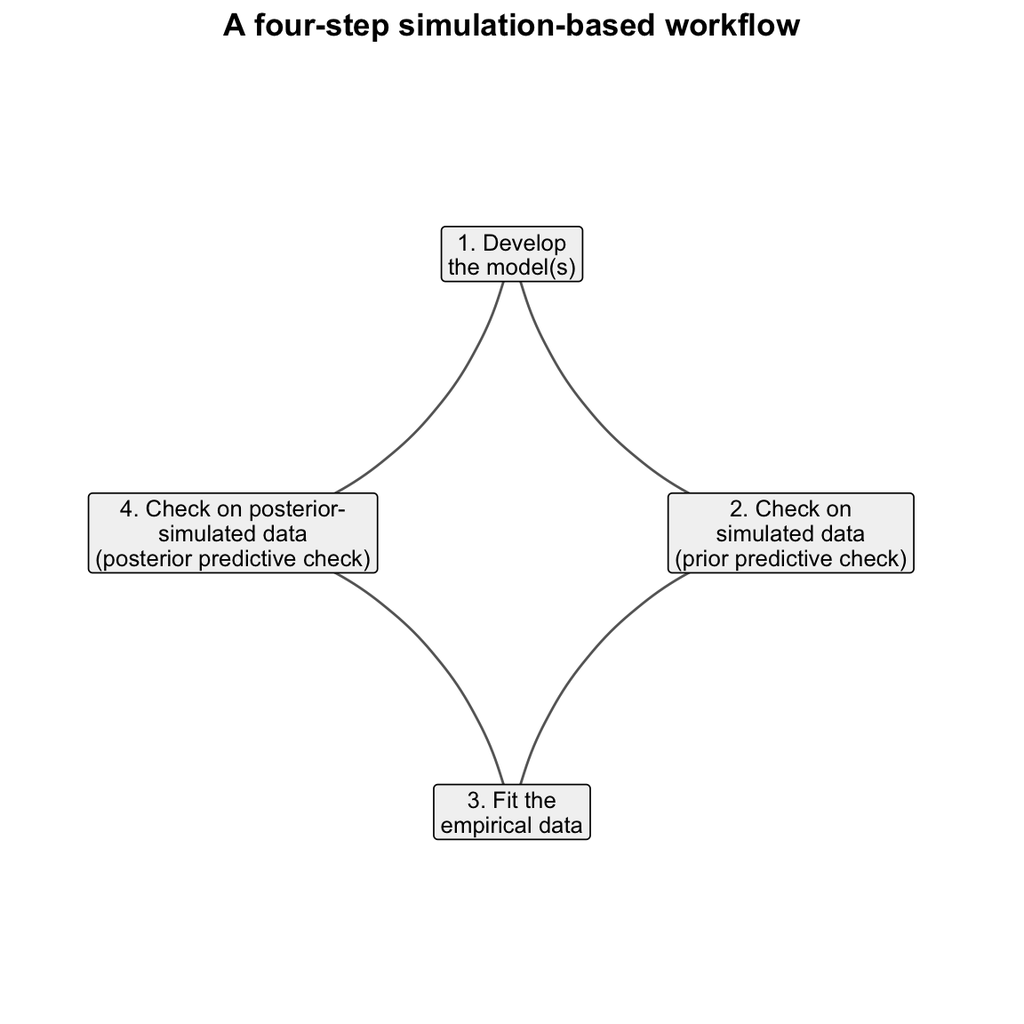

Figure 1: The four-step, iterative, simulation-based workflow described by Wolkovich *et al.* (2026) — my own redrawing of the logic in their Figure 1, not a reproduction of the original image.

```r
steps <- tibble(
  step  = 1:4,
  label = c("1. Develop\nthe model(s)",
            "2. Check on\nsimulated data\n(prior predictive check)",
            "3. Fit the\nempirical data",
            "4. Check on posterior-\nsimulated data\n(posterior predictive check)"),
  angle = seq(90, 90 - 270, length.out = 4) * pi / 180,
  x     = cos(angle),
  y     = sin(angle)
)

loop <- steps |>
  mutate(xend = lead(x, default = first(x)),
         yend = lead(y, default = first(y)))

ggplot(steps, aes(x, y)) +
  geom_curve(data = loop, aes(x = x, y = y, xend = xend, yend = yend),
             curvature = 0.3, arrow = arrow(length = unit(0.2, "cm")),
             color = "grey40") +
  geom_label(aes(label = label), size = 3.4, label.size = 0.3,
             fill = "grey95", lineheight = 0.9) +
  coord_equal(xlim = c(-1.6, 1.6), ylim = c(-1.6, 1.6)) +
  theme_void() +
  labs(title = "A four-step simulation-based workflow") +
  theme(plot.title = element_text(hjust = 0.5, face = "bold"))
```

This notebook is entirely about step 2: before I ever fit a model to real data, I want to see what my priors actually imply, on a scale I can reason about, so I can catch a badly-specified prior while it’s still cheap to fix.

## Building blocks: some distributions I reach for often

Before getting to priors for actual model parameters, it helps to have an intuitive feel for the distributions I use most often as building blocks. If you want more detail than I give here, Michael Franke’s notes on [selected continuous distributions](https://michael-franke.github.io/intro-data-analysis/selected-continuous-distributions-of-random-variables.html) are a good reference.

### Gamma & Exponential

Both distributions are defined only for positive values, which makes them natural priors for anything that must be positive — a rate, a duration, or, as I’ll use them below, a standard deviation.

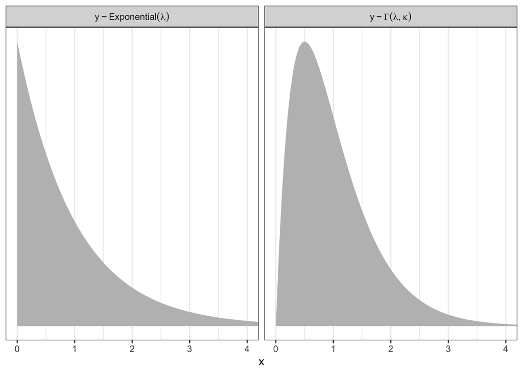

Figure 2: A Gamma(2, 2) density and an Exponential(1) density, both defined only for positive values.

```r
length_out <- 100

tibble(x = seq(from = 0, to = 5, length.out = length_out)) %>%
  mutate(Gamma       = dgamma(x, 2, 2),
         Exponential = dexp(x)) %>%
  pivot_longer(-x, values_to = "density") %>%
  mutate(label = ifelse(name == "Gamma", "y %~% Gamma(lambda, kappa)", "y %~% Exponential(lambda)")) %>%

  ggplot(aes(x = x, y = density)) +
  geom_area(fill = "grey") +
  scale_y_continuous(NULL, breaks = NULL) +
  coord_cartesian(xlim = c(0, 4)) +
  theme_bw() +
  facet_wrap(~ label, scales = "free_y", labeller = label_parsed)
```

### Poisson

The Poisson is my default building block whenever I’m modeling counts: always a non-negative integer, with a single parameter $\lambda$ controlling both its mean and its variance.

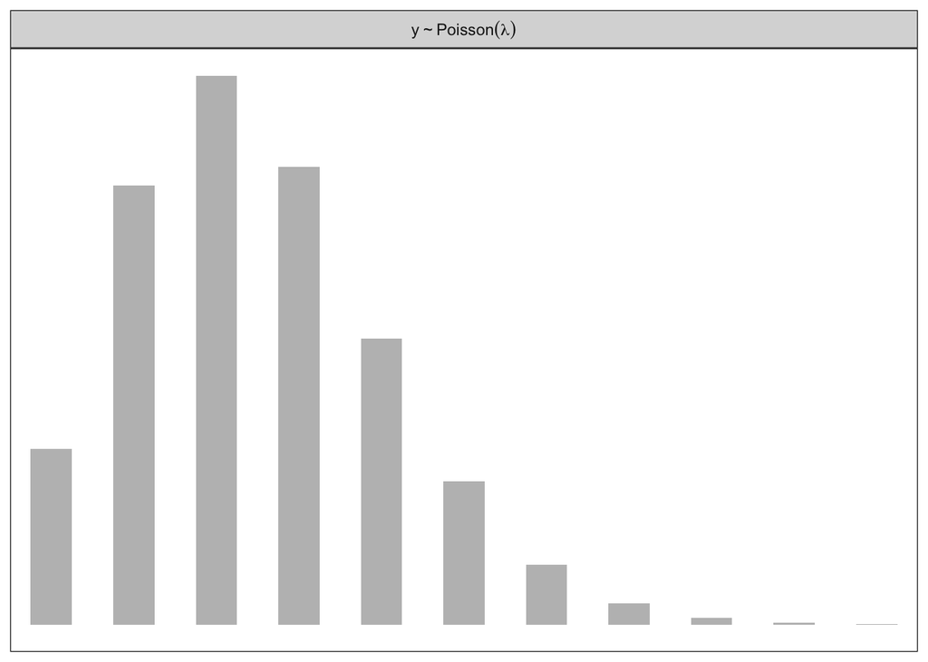

Figure 3: A Poisson(2.5) probability mass function.

```r
tibble(x = 0:20) %>%
  mutate(density = dpois(x, lambda = 2.5),
         strip   = "y %~% Poisson(lambda)") %>%

  ggplot(aes(x = x, y = density)) +
  geom_col(fill = "grey", width = 1/2) +
  scale_x_continuous(NULL, breaks = NULL) +
  scale_y_continuous(NULL, breaks = NULL) +
  coord_cartesian(xlim = c(0, 10)) +
  theme_bw() +
  facet_wrap(~ strip, labeller = label_parsed)
```

### Binomial

The Binomial is the natural choice for modeling a number of successes out of a fixed number of trials.

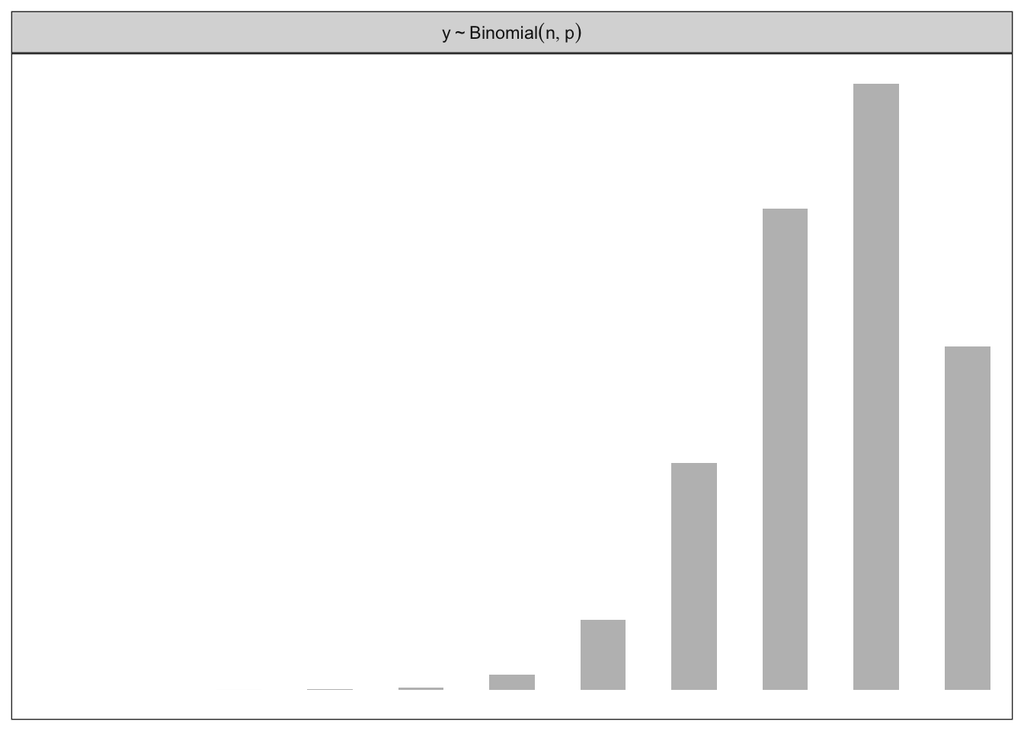

Figure 4: A Binomial(n = 10, p = 0.85) probability mass function.

```r
tibble(x = 0:10) %>%
  mutate(density = dbinom(x, size = 10, prob = .85),
         strip   = "y %~% Binomial(n, p)") %>%

  ggplot(aes(x = x, y = density)) +
  geom_col(fill = "grey", width = 1/2) +
  scale_x_continuous(NULL, breaks = NULL) +
  scale_y_continuous(NULL, breaks = NULL) +
  coord_cartesian(xlim = c(0, 10)) +
  theme_bw() +
  facet_wrap(~ strip, labeller = label_parsed)
```

## Priors for regression coefficients: slopes & intercepts

### Gaussian

A Normal (Gaussian) prior is my usual starting point for a regression coefficient, because I control its behavior with just two numbers — a mean and a standard deviation — and it’s easy to reason about what a given standard deviation implies once I plot it. Figure 5 compares three specifications side by side:

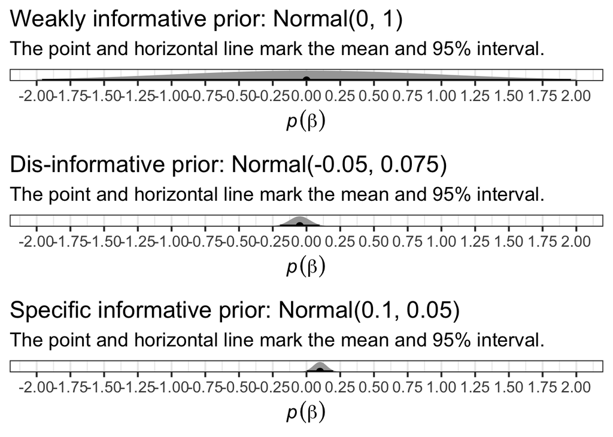

Figure 5: Three Gaussian priors for a regression coefficient, compared side by side. The point and horizontal line under each curve mark the mean and 95% interval.

```r
n1 <- prior(normal(0, 1), class = sd) %>%
  parse_dist()

pn1 <-  ggplot(n1, aes(y = 0, dist = .dist, args = .args)) +
  stat_halfeye(point_interval = mean_qi, .width = .95,
               p_limits = c(.0001, .9999)) +
  scale_y_continuous(NULL, breaks = NULL) +
 scale_x_continuous(breaks = seq(from = -2, to = 2, by = 0.25), limits = c(-2,2))+
  theme_bw(base_size = 16)+
  labs(title = "Weakly informative prior: Normal(0, 1)",
       subtitle = "The point and horizontal line mark the mean and 95% interval.",
       x = expression(italic(p)(beta)))

n2 <- prior(normal(-0.05, 0.075), class = sd) %>%
  parse_dist()

pn2 <- ggplot(n2, aes(y = 0, dist = .dist, args = .args)) +
  stat_halfeye(point_interval = mean_qi, .width = .95,
               p_limits = c(.0001, .9999)) +
  scale_y_continuous(NULL, breaks = NULL) +
 scale_x_continuous(breaks = seq(from = -2, to = 2, by = 0.25), limits = c(-2,2))+
  theme_bw(base_size = 16)+
  labs(title = "Dis-informative prior: Normal(-0.05, 0.075)",
       subtitle = "The point and horizontal line mark the mean and 95% interval.",
       x = expression(italic(p)(beta)))

n3 <- prior(normal(0.1, 0.05), class = sd) %>%
  parse_dist()

pn3 <- ggplot(n3, aes(y = 0, dist = .dist, args = .args)) +
  stat_halfeye(point_interval = mean_qi, .width = .95,
               p_limits = c(.0001, .9999)) +
  scale_y_continuous(NULL, breaks = NULL) +
 scale_x_continuous(breaks = seq(from = -2, to = 2, by = 0.25), limits = c(-2,2))+
  theme_bw(base_size = 16)+
  labs(title = "Specific informative prior: Normal(0.1, 0.05)",
       subtitle = "The point and horizontal line mark the mean and 95% interval.",
       x = expression(italic(p)(beta)))

ggarrange(pn1, pn2, pn3, nrow = 3)
```

Looking at the three side by side is the whole point: the “weakly informative” $\text{Normal}(0, 1)$ prior spreads most of its mass between roughly $-2$ and $2$ — I’m telling the model I have almost no idea what sign or size the effect will be. The “dis-informative” one is deliberately a cautionary example: it’s just as narrow as the third prior, but centered close to zero with no strong justification for that particular band, which is the kind of prior that quietly fights the data if I haven’t thought it through. The “specific informative” prior is what a *justified* narrow prior looks like — I’m telling the model I’m already fairly confident, from previous studies or domain knowledge, that the effect is small and positive, close to 0.1.

## Priors for sigma

Sigma is the estimated standard deviation of the residuals — in an intercept-only model, this is identical to the standard deviation of the outcome itself. Because it’s a standard deviation, it has to be positive, which rules out the Gaussian and points me toward distributions defined only on the positive half-line.

### Exponential

The exponential distribution has a single parameter, $\lambda$, the reciprocal of the mean. Figure 6 shows how larger $\lambda$ concentrates the density closer to zero — useful when I already expect small residual variation — while smaller $\lambda$ spreads the density out, useful when I’m more uncertain.

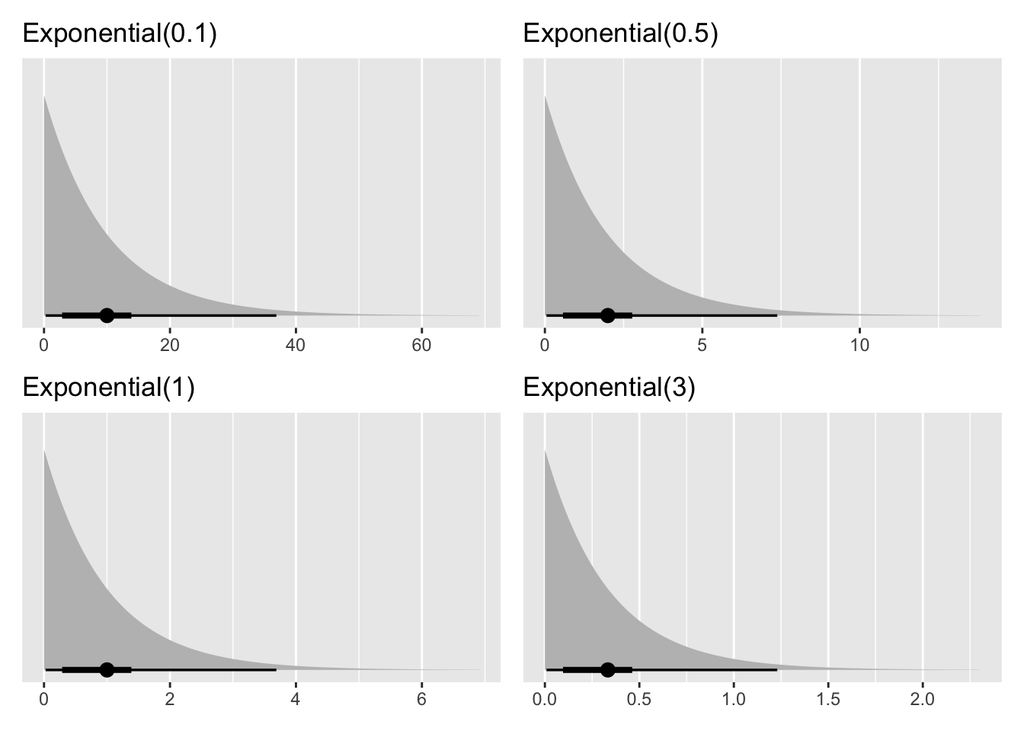

Figure 6: Four Exponential priors for a scale parameter, with increasing rate lambda concentrating the density closer to zero.

```r
p0 <- prior(exponential(0.1)) %>%
  ggdist::parse_dist() %>%
  ggplot(aes(y = 0, dist = .dist, args = .args)) +
  ggdist::stat_halfeye(point_interval = mean_qi, .width = c(.5, .95),
               fill = "grey") +
  scale_y_continuous(NULL, breaks = NULL) +
  labs(title = "Exponential(0.1)",
       x = NULL)

p0_5 <- prior(exponential(0.5)) %>%
  ggdist::parse_dist() %>%
  ggplot(aes(y = 0, dist = .dist, args = .args)) +
  ggdist::stat_halfeye(point_interval = mean_qi, .width = c(.5, .95),
               fill = "grey") +
  scale_y_continuous(NULL, breaks = NULL) +
  labs(title = "Exponential(0.5)",
       x = NULL)

p1 <- prior(exponential(1)) %>%
  ggdist::parse_dist() %>%
  ggplot(aes(y = 0, dist = .dist, args = .args)) +
  ggdist::stat_halfeye(point_interval = mean_qi, .width = c(.5, .95),
               fill = "grey") +
  scale_y_continuous(NULL, breaks = NULL) +
  labs(title = "Exponential(1)",
       x = NULL)

p2 <- prior(exponential(3)) %>%
  ggdist::parse_dist() %>%
  ggplot(aes(y = 0, dist = .dist, args = .args)) +
  ggdist::stat_halfeye(point_interval = mean_qi, .width = c(.5, .95),
               fill = "grey") +
  scale_y_continuous(NULL, breaks = NULL) +
  labs(title = "Exponential(3)",
       x = NULL)

p0 + p0_5 + p1 + p2
```

### Half-Cauchy

The Half-Cauchy is a common choice for scale parameters in hierarchical models, following the recommendation in Gelman (2006) — it’s “half” because only the positive values are kept, since a standard deviation can only ever be positive, and its heavy tail means it doesn’t rule out a surprisingly large residual variance the way a lighter-tailed prior would. Figure 7 shows how the scale parameter controls how much mass sits near zero versus out in the tail.

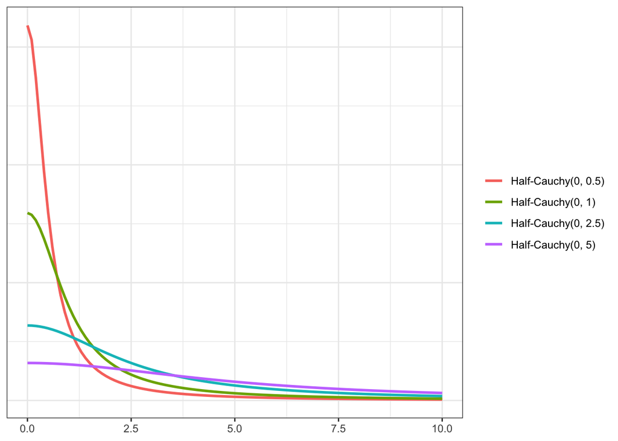

Figure 7: Half-Cauchy densities with location 0 and varying scale, following the recommendation in Gelman (2006) for scale-parameter priors in hierarchical models.

```r
tibble(scale = c( 0.5, 1, 2.5, 5)) %>%
  crossing(x = seq(0, 10, 0.1)) %>%
  mutate(
    prior = str_c("Half-Cauchy(0, ", scale, ")"),
    dens = dcauchy(x, location = 0, scale = scale)
  ) %>%
  ggplot(aes(x, y = dens)) +
  geom_line(aes(color = prior), linewidth = 1) +
  theme_bw() +
  labs(x = NULL, y = NULL, color = NULL) +
  theme(axis.ticks.y = element_blank(), axis.text.y = element_blank())
```

### Gamma

McElreath’s `rethinking` package reparameterizes the Gamma distribution in terms of its mean `mu` and a `scale` parameter, instead of the usual shape and rate — which I find much easier to reason about when I’m choosing a prior mean directly. Rather than installing the whole package just for this one function, I reimplemented it here following its published source (McElreath 2024):

```r
# Reparameterizes the Gamma distribution in terms of its mean (mu) and a
# scale parameter, following rethinking::dgamma2() [@rethinkingpkg]:
# dgamma2(x, mu, scale) = dgamma(x, shape = mu / scale, scale = scale)
dgamma2 <- function(x, mu, scale, log = FALSE) {
  dgamma(x, shape = mu / scale, scale = scale, log = log)
}
```

Figure 8 shows how flexible the Gamma family is: the same distribution family can look like a spike near zero or a broad, almost-symmetric hump, entirely depending on how I set its mean and scale.

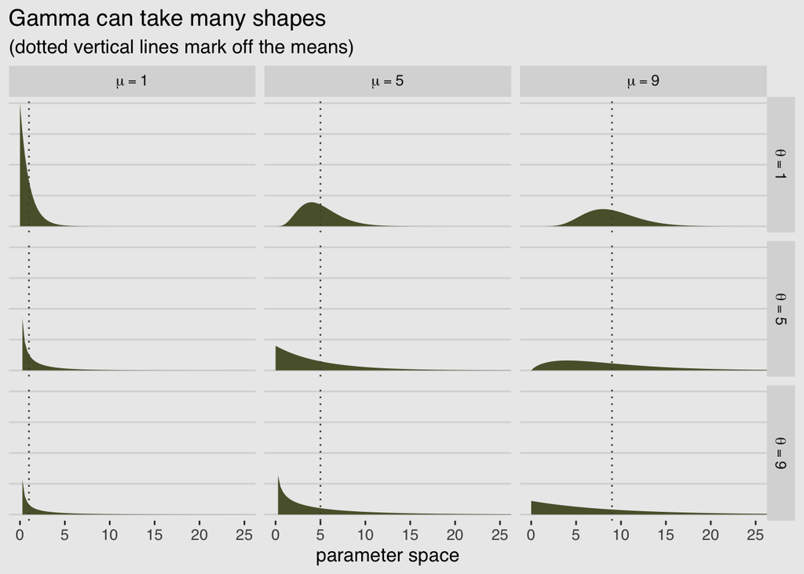

Figure 8: Gamma densities across a grid of mean (mu) and scale (theta) values. Dotted vertical lines mark the mean of each density.

```r
crossing(mu    = c(1, 5, 9),
         theta = c(1, 5, 9)) %>%
  expand_grid(x = seq(from = 0, to = 27, length.out = 100)) %>%
  mutate(density    = dgamma2(x, mu, theta),
         mu_char    = str_c("mu==", mu),
         theta_char = str_c("theta==", theta)) %>%

  ggplot() +
  geom_area(aes(x = x, y = density),
            fill = canva_pal("Green fields")(4)[4]) +
  geom_vline(aes(xintercept = mu),
             color = canva_pal("Green fields")(4)[2], linetype = 3) +
  scale_y_continuous(NULL, labels = NULL) +
  labs(title = "Gamma can take many shapes",
       subtitle = "(dotted vertical lines mark off the means)",
       x = "parameter space") +
  coord_cartesian(xlim = c(0, 25)) +
  theme_hc() +
  theme(axis.ticks.y = element_blank(),
        plot.background = element_rect(fill = "grey92")) +
  facet_grid(theta_char~mu_char, labeller = label_parsed)
```

## Comparing candidate priors on sigma directly

Something I like to remind myself: if you take the log of a log-normal distribution, you end up with a normal distribution, and vice versa. So a normal prior on `log(sigma)` is, by definition, a log-normal prior on `sigma` itself — a normal prior on the log link is the same thing as a log-normal prior on the identity link.

Putting several candidate priors for sigma on the same plot, on the natural (identity) scale, is how I actually decide between them:

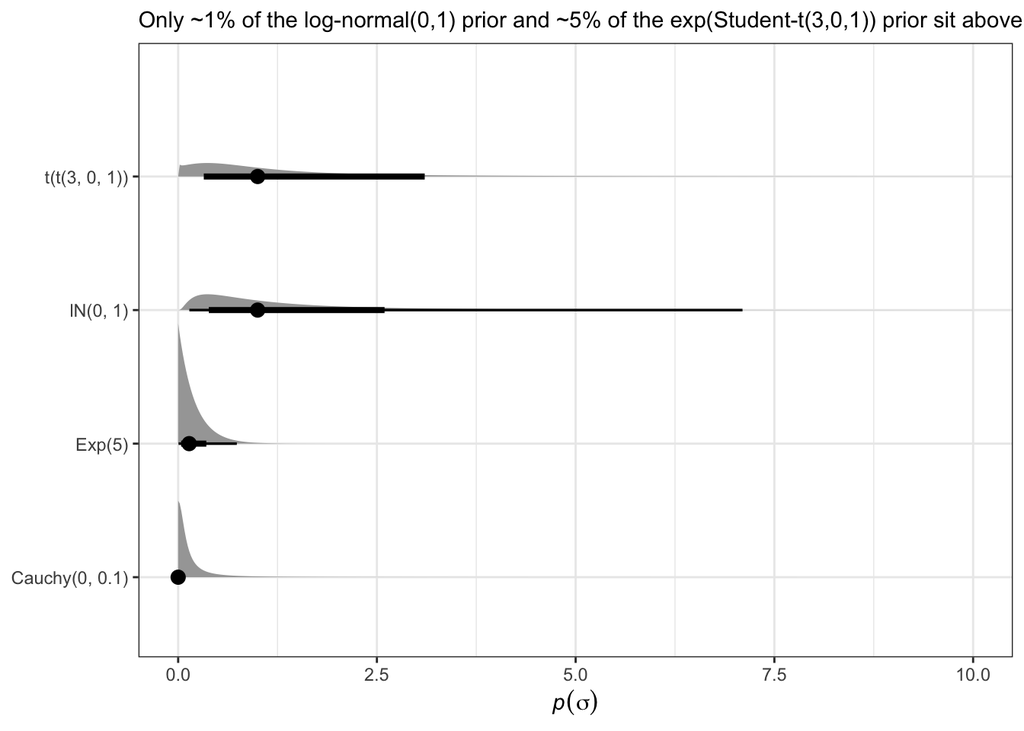

Figure 9: Four candidate priors for a scale parameter (sigma), compared on the identity scale.

```r
sigma_priors <- data.frame(sigma = c(exp(dist_normal(0,1)), # exp because brms models log(sigma)
                     exp(dist_student_t(3, 0, 1)),
                      dist_cauchy(location = 0, scale = 0.1),
                       dist_exponential(5)
                     ))

sigma_priors |>
     ggplot(aes(xdist = sigma,  y = as.character(sigma))) +
     stat_halfeye(p_limits = c(0, 0.975))+
  theme_bw()+
  scale_x_continuous(expression(italic(p)(sigma)), limits = c(0,10))+
  labs(subtitle = "Only ~1% of the log-normal(0,1) prior and ~5% of the exp(Student-t(3,0,1)) prior sit above 10; essentially none of the Exponential(5) prior does.",
       y= NULL)
```

The four priors look deceptively similar near zero, but they disagree sharply about how much mass they place on implausibly large values of sigma — and that tail is exactly where a prior can quietly let an unrealistic model fit pass the check. Concretely: about 1.1% of the log-normal(0,1) prior’s density sits above 10, versus about 5.2% for the heavier-tailed prior built from a Student-t, roughly 0.3% for the Half-Cauchy(0, 0.1), and effectively 0% for the Exponential(5) — even though all four look like reasonable, unremarkable priors for sigma at first glance.

## A worked example: putting it together

As a concrete example, here’s how I approached priors for a real regression I fit, where the outcome was the change in dissolved organic carbon (“delta DOC”) in a set of ponds, and the main predictor was pond water volume. I go through the same steps I’ve used throughout this notebook — plot the intercept prior, plot the slope prior, and actually check what the slope prior implies in probability terms, not just by eyeballing the plot.

[figure not shown]

```r
# Intercept of delta DOC: its value when pond water volume is at its average.
n1 <- prior(normal(0, 5), class = sd) %>%
  parse_dist()

pn1 <-  ggplot(n1, aes(y = 0, dist = .dist, args = .args)) +
  stat_halfeye(point_interval = mean_qi, .width = .95,
               p_limits = c(.0001, .9999)) +
  scale_y_continuous(NULL, breaks = NULL) +
 scale_x_continuous(breaks = seq(from = -15, to = 15, by = 2.5), limits = c(-15,15))+
  theme_bw(base_size = 16)+
  labs(title = "Intercept prior: Normal(0, 5)",
       subtitle = "The point and horizontal line mark the mean and 95% interval.",
       x = expression(italic(p)(beta[0])))

# Slope: how much pond water volume influences delta DOC.
n2 <- prior(normal(-0.2, 0.25), class = sd) %>%
  parse_dist()

pn2 <- ggplot(n2, aes(y = 0, dist = .dist, args = .args)) +
  stat_halfeye(point_interval = mean_qi, .width = .95,
               p_limits = c(.0001, .9999)) +
  scale_y_continuous(NULL, breaks = NULL) +
 scale_x_continuous(breaks = seq(from = -1, to = 1, by = 0.25), limits = c(-1,1))+
  theme_bw(base_size = 16)+
  labs(title = "Pond water volume prior: Normal(-0.2, 0.25)",
       subtitle = "There is almost 20% prior probability that the slope is > 0",
       x = expression(italic(p)(beta[1])))

# Student-t scale parameter
n3 <- prior(lognormal(0, 1), class = sd) %>%
  parse_dist()

pn3 <- ggplot(n3, aes(y = 0, dist = .dist, args = .args)) +
  stat_halfeye(point_interval = mean_qi, .width = .95,
               p_limits = c(.0001, .9999)) +
  scale_y_continuous(NULL, breaks = NULL) +
  theme_bw(base_size = 16)+
  labs(title = "Student-t scale parameter prior: Lognormal(0, 1)",
       x = expression(italic(p)(s)))

# Student-t nu (degrees of freedom) parameter
n4 <- prior(gamma(2, 1)) %>%
  parse_dist()

pn4 <- ggplot(n4, aes(y = 0, dist = .dist, args = .args)) +
  stat_halfeye(point_interval = mean_qi, .width = .95,
               p_limits = c(.0001, .9999)) +
  scale_y_continuous(NULL, breaks = NULL) +
 scale_x_continuous(breaks = seq(from = 0, to = 9, by = 1.5), limits= c(0,9))+
  theme_bw(base_size = 16)+
  labs(title = "Student-t nu parameter prior: Gamma(2, 1)",
       x = expression(italic(p)(s)))

ggarrange(pn1, pn2, pn3, pn4, nrow = 4)
```

I don’t just trust the plot of the slope prior by eye — I also check the probability directly, which is easy to get wrong just by looking at a density curve:

```r
tibble(beta_1 = rnorm(n = 10000, mean = -0.2, sd = 0.25))  |>
  count(beta_1 > 0) |>
  mutate(percent = 100 * n / sum(n))
```

```
# A tibble: 2 × 3
  `beta_1 > 0`     n percent
  <lgl>        <int>   <dbl>
1 FALSE         7878    78.8
2 TRUE          2122    21.2
```

So even though the slope prior is centered on a negative effect (more pond water volume associated with less delta DOC), it still leaves close to 20% prior probability that the effect could go the other way. That’s the kind of check I can only really trust once I’ve actually computed it — the plot alone made me underestimate how much probability was sitting on the “wrong” side of zero.

## References

Gelman, A. (2006). [Prior distributions for variance parameters in hierarchical models](https://doi.org/10.1214/06-BA117A). *Bayesian Analysis*, 1, 515–534.

McElreath, R. (2020). *Statistical rethinking: A Bayesian course with examples in R and Stan*. 2nd edn. CRC Press, Boca Raton, FL.

McElreath, R. (2024). [Rethinking: Statistical rethinking course and package](https://github.com/rmcelreath/rethinking).

Wolkovich, E.M., Davies, T.J., Pearse, W.D. & Betancourt, M. (2026). [A four-step simulation-based workflow for ecological analysis and science](https://doi.org/10.1098/rsta.2025.0252). *Philosophical Transactions of the Royal Society A*, 384, 20250252.